# Import libraries

```python
import pandas as pd
import matplotlib.pyplot as plt
```

# Import dataset

```python
df=pd.read_excel('C:\\Users\\arpit\\Downloads\\Master.xlsx')
print(df)
```

```
    PETRO CARD NO  TOKEN ID     VEHICLE NO           MODEL TRANSMISSION  \
0    FC0108719559    203505  DL-8C-AU-2787         XUV 5OO    AUTOMATIC
1    FC0026782069  25005101  DL-8C-AY-0922         XUV 5OO       MANUAL
2    FC0005694996    211187  DL-8C-AY-5677  ALTURAS G4 AWD    AUTOMATIC
3    FC0273416064    211187  DL-8C-AY-5677  ALTURAS G4 AWD    AUTOMATIC
4    FC0005694749  25000421      GENERATOR             NaN          NaN
..            ...       ...            ...             ...          ...
142  FC0013800312  23100962  WB-20-BE-7622         XUV 5OO       MANUAL
143  FC0005694129  23192481  MH-01-AL-2011            XYLO          NaN
144  FC0280132431  23148746  MH-01-DK-7948         XUV 5OO          NaN
145  FC0280132399  23137649  MH-01-DK-7943         XUV 5OO          NaN
146  FC0278695431  23157934  MH-02-EP-6122  MARUTI CELERIO          NaN

       FUEL  STATUS
0    DIESEL  ACTIVE
1    DIESEL  ACTIVE
2    DIESEL  ACTIVE
3    DIESEL  ACTIVE
4    DIESEL  ACTIVE
..      ...     ...
142  DIESEL  ACTIVE
143  DIESEL  ACTIVE
144  DIESEL  ACTIVE
145  DIESEL  ACTIVE
146  PETROL  ACTIVE

[147 rows x 7 columns]
```

# Identification of variable:-As we know Master.xlsx dataset contains both continuous and categorical variable with first six column as Independent variable and last column as Dependent variable.

# Identification of datatype

```python
print(df.dtypes)
```

```
PETRO CARD NO    object
TOKEN ID          int64
VEHICLE NO       object
MODEL            object
TRANSMISSION     object
FUEL             object
STATUS           object
dtype: object
```

# Identification of Size for dataset

```python
print(df.shape)
```

```
(147, 7)
```

# Identification of Stats for dataset

```python
print(df.describe())
```

```
           TOKEN ID
count  1.470000e+02
mean   1.390835e+07
std    1.139847e+07
min    2.000250e+05
25%    2.082200e+05
50%    2.309664e+07
75%    2.319248e+07
max    2.500510e+07
```

# Find out the missing value in the dataset

```python
print(df.apply(lambda x: sum(x.isnull()),axis=0))
```

```
PETRO CARD NO    0
TOKEN ID         0
VEHICLE NO       1
MODEL            3
TRANSMISSION     7
FUEL             0
STATUS           0
dtype: int64
```

# Variable 1:-PETROCARDNO

```python
print(df['PETRO CARD NO'].unique())
print(df['PETRO CARD NO'].nunique())
```

```
['FC0108719559' 'FC0026782069' 'FC0005694996' 'FC0273416064'
 'FC0005694749' 'FC0005695431' 'FC0005694673' 'FC0013800270'
 'FC0005695027' 'FC0005694137' 'FC7005694129' 'FC0005694160'
 'FC0005694269' 'FC0005695282' 'FC0005695159' 'FC0005695209'
 'FC0014934508' 'FC0005694343' 'FC0005694863' 'FC0005695217'
 'FC0005694699' 'FC0005694087' 'FC0005694285' 'FC0005694624'
 'FC0005695084' 'FC0005694152' 'FC0005695480' 'FC0005694574'
 'FC0005695472' 'FC0005695464' 'FC0005694061' 'FC0005694319'
 'FC0005695316' 'FC0005694582' 'FC0005695290' 'FC0005695233'
 'FC0005694541' 'FC0006277189' 'FC0005694871' 'FC0005694764'
 'FC0005694962' 'FC0005694301' 'FC0005694178' 'FC0005694558'
 'FC0005694681' 'FC0005694566' 'FC0005694970' 'FC0005694772'
 'FC0005694905' 'FC0005694897' 'FC0005694400' 'FC0005694947'
 'FC0005694145' 'FC0005694640' 'FC0005694806' 'FC0005694715'
 'FC0005695134' 'FC0005694392' 'FC0005694079' 'FC0005694426'
 'FC0005695324' 'FC0005695332' 'FC0005694731' 'FC0005694418'
 'FC0005695365' 'FC0005694384' 'FC0005694046' 'FC0005694376'
 'FC0005694798' 'FC0005694988' 'FC0005694889' 'FC0005694012'
 'FC0005694442' 'FC0005695241' 'FC0006277148' 'FC0005694665'
 'FC0005694103' 'FC0005695373' 'FC0005693998' 'FC0005694509'
 'FC0005695118' 'FC0005694848' 'FC0005695381' 'FC0005694533'
 'FC0005694004' 'FC0005695076' 'FC0005694244' 'FC0062016950'
 'FC0005694236' 'FC0005695415' 'FC0005694434' 'FC0005694921'
 'FC0005693980' 'FC0005695043' 'FC0005694210' 'FC0005695399'
 'FC0005695225' 'FC0005694020' 'FC0005695407' 'FC0005694038'
 'FC0005694475' 'FC0005694491' 'FC0005694616' 'FC0006277171'
 'FC0005694111' 'FC0005694780' 'FC0005695126' 'FC0005695050'
 'FC0005695340' 'FC0005695183' 'FC0005695449' 'FC0005694459'
 'FC0005694913' 'FC0005695274' 'FC0005695167' 'FC0269754700'
 'FC0005694954' 'FC0005695423' 'FC0005694707' 'FC0272414920'
 'FC0005694293' 'FC0273929587' 'FC0005695092' 'FC0005694830'
 'FC0005694053' 'FC0005695019' 'FC0005695456' 'FC0273372572'
 'FC0273368174' 'FC0104951362' 'FC0270028912' 'FC0006276868'
 'FC0005694590' 'FC0005694483' 'FC0005695100' 'FC0005694277'
 'FC0005695035' 'FC0005694723' 'FC0014114614' 'FC0272231423'
 'FC0005694517' 'FC0120933618' 'FC0013800312' 'FC0005694129'
 'FC0280132431' 'FC0280132399' 'FC0278695431']
147
```

# Find out the total count of the data_item using value_counts()

```python
print(df['PETRO CARD NO'].value_counts())
```

```
FC0005694541    1
FC0005694293    1
FC0005694491    1
FC0005694574    1
FC0005694665    1
               ..
FC0005695290    1
FC0273929587    1
FC0005695050    1
FC0273372572    1
FC0013800270    1
Name: PETRO CARD NO, Length: 147, dtype: int64
```

# Ans:-Bar Graph is generally used to differentiate or compare categories of a particular column which means that by the use of value_counts() we can get the count of each category i.e.data_item of a particular column and then we plot each category on the graph and we see there value_count on the Y-axis and then we could differentiate between all the categories.

# What is X-axis in bar graph

# Ans:-X-axis in bar graph shows the data_item or the category of a particular coulmn.

# What is Y-axis in bar graph

# Ans:-Y-axis in bar graph shows the total_count of each data_item in the form of a range.

# NOTE:-Bar Graph is always plotted within the y-axis means through y-axis we could differntiate between different categories of a particular column.

# Plotting of graph using Bar Graph:-As we know that the PETRO CARD NO is a obejct type variable which means that this variable contain more data so we are plotting only the top 5 data_items as each data_item has a value count of 1.

```
<BarContainer object of 5 artists>
```

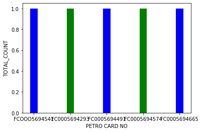

```python
x=["FCOOO5694541","FC0005694293","FC0005694491","FC0005694574","FC0005694665"]
y=[1]
plt.xlabel('PETRO CARD NO')
plt.ylabel('TOTAL_COUNT')
plt.bar(x,y,width =0.2,color =['blue','green'])
```

# Variable 2:-TOKEN ID

```python
print(df['TOKEN ID'].unique())
print(df['TOKEN ID'].nunique())
```

```
[  203505 25005101   211187 25000421 23061454 23149398 23061475 23192481
   204364 23010021   214830   210613   200025 23144970 23151702 23135551
   206174 23148131 23155311   200577 23162160   209105   214609   201661
 23163907   203380   202214 23137327   215372 23166736   200755   208071
 23247001   200720   211002   203610 23167137   209479 23172291 23066772
   200895 23075752   215250 23061476   201508   206923   212834   205045
   200238 23200122 23103492 23073922   203656   213593 23082897 23172838
   204911   206055   201273 23103379 23106941 25001212 23061155 25001262
 25001858   209397 24009256   206814   208492   215667   214612 23096645
 23141621   200785   204132   208607   204912   208989   207624   215419
   208369 23062237 23010044   206575   200256 23092538  2214238   212752
 23100962 23148746 23137649 23157934]
92
```

# Find the total count of the data_item using value_count()

```python
print(df['TOKEN ID'].value_counts())
```

```
23192481    37
25000421     4
200720       3
23141621     3
200238       2
            ..
23061155     1
23075752     1
23157934     1
210613       1
23163907     1
Name: TOKEN ID, Length: 92, dtype: int64
```

# Plotting of graph using bar graph:-As we know that Token id is an integer type data which means it is a type of continuous variable so for continuous variable bar graph doesnot show proper analysis because data is more so we only plot for top 5 data hence for each data_item we doesnot plot bar garph that's why bar graph does not give proper analysis for continuous variable and here we could see that highest total_count is 37.

```
<BarContainer object of 5 artists>
```

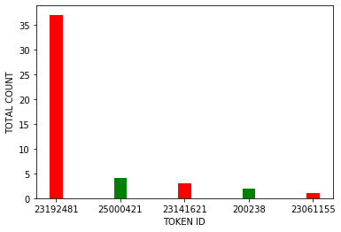

```python
x=["23192481","25000421","23141621","200238","23061155"]
y=[37,4,3,2,1]
plt.xlabel('TOKEN ID')
plt.ylabel('TOTAL COUNT')
plt.bar(x,y,width =0.2,color =['red','green'])
```